# Model_Supplement

Ana Miller-ter Kuile

6/26/2020

# Diet Measure Models

## 1. Prey Detection

### A. Mesocosm

For mesocosm consumers, the full model is of the form:

**presence ~ Sterilized, family = binomial**

where **presence** is the binary 0-1 detection of the offered prey item (*Oxya japonica*) in the sample and **Sterilized** is a two-level factor of either *surface sterilized* or *not surface sterilized*.

and the null model is:

**presence ~ 1, family = binomial**

```r
AICc(lab_detect_mod, lab_null_model)
```

|  | df | AICc |
| --- | --- | --- |
| lab_detect_mod | 2 | 22.54235 |
| lab_null_model | 1 | 24.13599 |

#### Model summary

p-value of the surface sterilization fixed effect as marginally significant:

```r
summary(lab_detect_mod)
```

```
##  Family: binomial  ( logit )
## Formula:          presence ~ Sterilized
## Data: lab_detect
##
##      AIC      BIC   logLik deviance df.resid
##     21.8     23.7     -8.9     17.8       17
##
##
## Conditional model:
##              Estimate Std. Error z value Pr(>|z|)
## (Intercept)     2.303      1.049   2.195   0.0281 *
## SterilizedSS   -2.303      1.265  -1.820   0.0687 .
## ---
## Signif. codes:  0 '***' 0.001 '**' 0.01 '*' 0.05 '.' 0.1 ' ' 1
```

#### Marginal means graph

A marginal means graph shows a decreased in detection with surface steriliation:

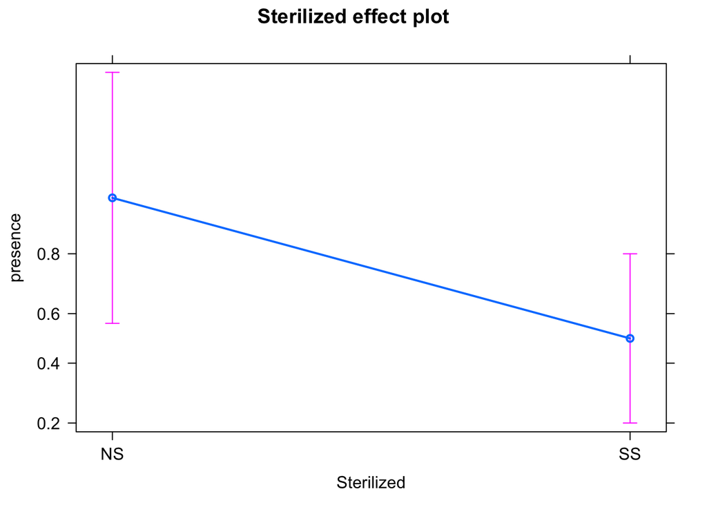

```r
plot(allEffects(lab_detect_mod))
```

#### Model diagnostics

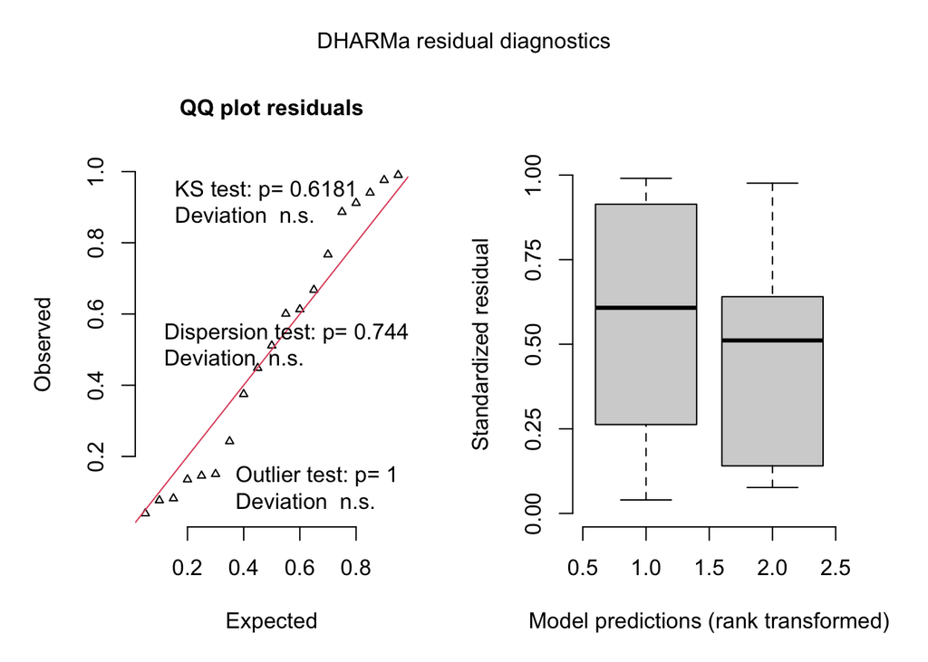

```r
simulationOutput_lab <- simulateResiduals(fittedModel = lab_detect_mod)
fit_lab <- plot(simulationOutput_lab, asFactor=TRUE)
```

```r
binned_residuals(lab_detect_mod)
```

```
## Ok: About 100% of the residuals are inside the error bounds.
```

|  | xbar | ybar | n | x.lo | x.hi | se | group |
| --- | --- | --- | --- | --- | --- | --- | --- |
| 1 | 0.5000003 | -3.138580e-07 | 8 | 0.5000003 | 0.5000003 | 0.3779645 | yes |
| 2 | 0.9090909 | -1.441618e-08 | 11 | 0.9090909 | 0.9090909 | 0.1818182 | yes |

### B. Natural

For natural consumers, the full model is of the form:

**presence ~ Sterilized, family = binomial**

where **presence** is the binary 0-1 detection of any potential prey in the sample and **Sterilized** is a two-level factor of either *surface sterilized* or *not surface sterilized*.

and the null model is:

**presence ~ 1, family = binomial**

#### Model comparison with AICc

```r
AICc(fld_detect_mod, fld_null_model)
```

|  | df | AICc |
| --- | --- | --- |
| fld_detect_mod | 2 | 29.69774 |
| fld_null_model | 1 | 27.46236 |

#### Model summary

The sterilized term is non-significant:

```r
summary(fld_detect_mod)
```

```
##  Family: binomial  ( logit )
## Formula:          presence ~ Sterilized
## Data: field_detect
##
##      AIC      BIC   logLik deviance df.resid
##     29.3     32.6    -12.7     25.3       35
##
##
## Conditional model:
##              Estimate Std. Error z value Pr(>|z|)
## (Intercept)   2.14007    0.74755   2.863   0.0042 **
## SterilizedSS -0.06063    1.05893  -0.057   0.9543
## ---
## Signif. codes:  0 '***' 0.001 '**' 0.01 '*' 0.05 '.' 0.1 ' ' 1
```

```r
summary(fld_null_model)
```

```
##  Family: binomial  ( logit )
## Formula:          presence ~ 1
## Data: field_detect
##
##      AIC      BIC   logLik deviance df.resid
##     27.3     29.0    -12.7     25.3       36
##
##
## Conditional model:
##             Estimate Std. Error z value Pr(>|z|)
## (Intercept)   2.1102     0.5294   3.986 6.73e-05 ***
## ---
## Signif. codes:  0 '***' 0.001 '**' 0.01 '*' 0.05 '.' 0.1 ' ' 1
```

#### Model diagnostics

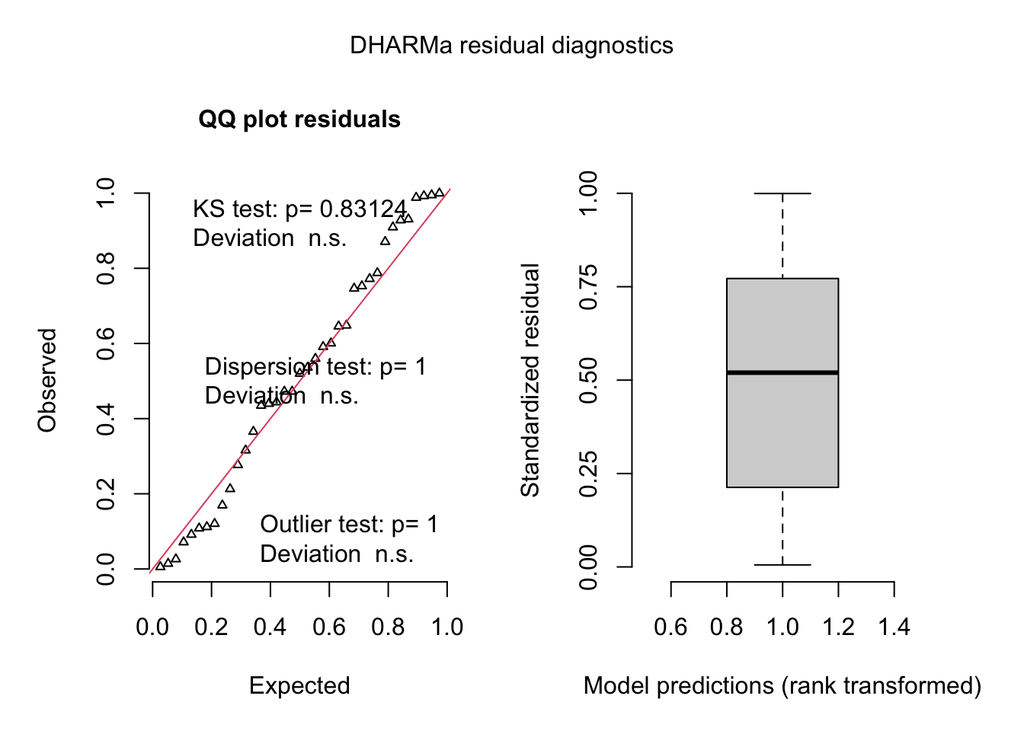

```r
simulationOutput_fld <- simulateResiduals(fittedModel = fld_null_model)
fit_fld <- plot(simulationOutput_fld, asFactor=TRUE)
```

```r
binned_residuals(fld_null_model)
```

```
## Ok: About 100% of the residuals are inside the error bounds.
```

|  | xbar | ybar | n | x.lo | x.hi | se | group |
| --- | --- | --- | --- | --- | --- | --- | --- |
| 1 | 0.8918919 | 2.18276e-10 | 37 | 0.8918919 | 0.8918919 | 0.1035056 | yes |

### C. Summary

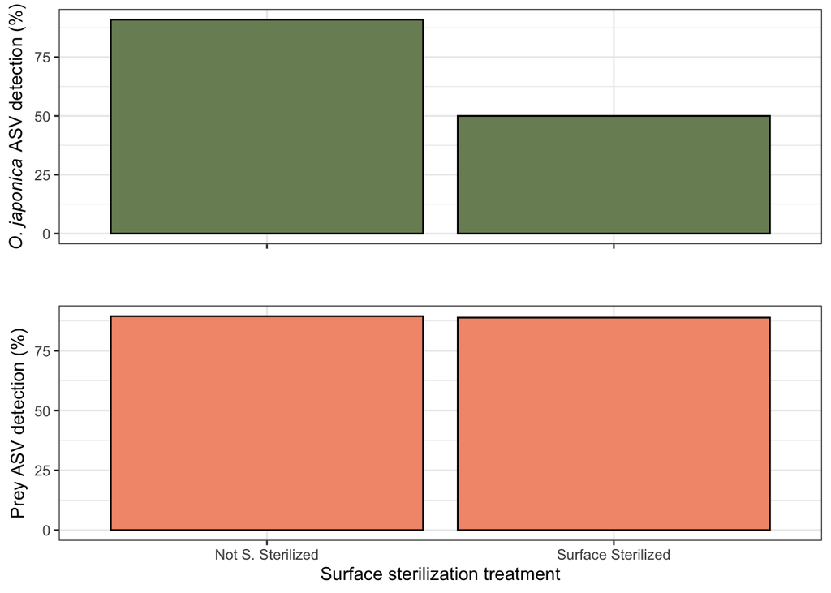

## 2. Prey DNA Abundance

### A. Mesocosm

For mesocosm consumers, the full model is of the form:

**offered prey ~ Sterilized, offset = log(total), family = “genpois”)**

where **offered prey** is the abundance of DNA from the offered prey item (*Oxya japonica*) in the sample, **Sterilized** is a two-level factor of either *surface sterilized* or *not surface sterilized*, and the offset term of **total** offset transforms the abundance value by the total DNA read abundance in the sample, since there is a huge spread in the raw DNA abundances.

and the null model is:

**offered prey ~ 1, offset = log(total), family = “genpois”)**

#### Model comparison with AICc

```r
AICc(lab_mod, lab_null)
```

|  | df | AICc |
| --- | --- | --- |
| lab_mod | 3 | 180.2187 |
| lab_null | 2 | 177.9251 |

#### Model summary

```r
summary(lab_mod)
```

```
##  Family: genpois  ( log )
## Formula:          known ~ Sterilized
## Data: lab_all_nz
##  Offset: log(total)
##
##      AIC      BIC   logLik deviance df.resid
##    177.8    179.7    -85.9    171.8       11
##
##
## Overdispersion parameter for genpois family (): 5.66e+03
##
## Conditional model:
##              Estimate Std. Error z value Pr(>|z|)
## (Intercept)   -4.6549     0.9358  -4.974 6.55e-07 ***
## SterilizedSS  -0.4906     0.5111  -0.960    0.337
## ---
## Signif. codes:  0 '***' 0.001 '**' 0.01 '*' 0.05 '.' 0.1 ' ' 1
```

```r
summary(lab_null)
```

```
##  Family: genpois  ( log )
## Formula:          known ~ 1
## Data: lab_all_nz
##  Offset: log(total)
##
##      AIC      BIC   logLik deviance df.resid
##    176.8    178.1    -86.4    172.8       12
##
##
## Overdispersion parameter for genpois family (): 5.92e+03
##
## Conditional model:
##             Estimate Std. Error z value Pr(>|z|)
## (Intercept)  -4.7723     0.9512  -5.017 5.24e-07 ***
## ---
## Signif. codes:  0 '***' 0.001 '**' 0.01 '*' 0.05 '.' 0.1 ' ' 1
```

#### Model diagnostics

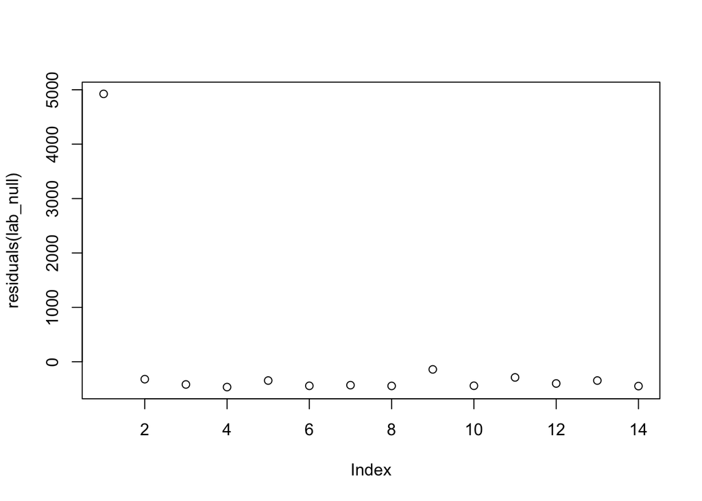

```r
plot(residuals(lab_null))
```

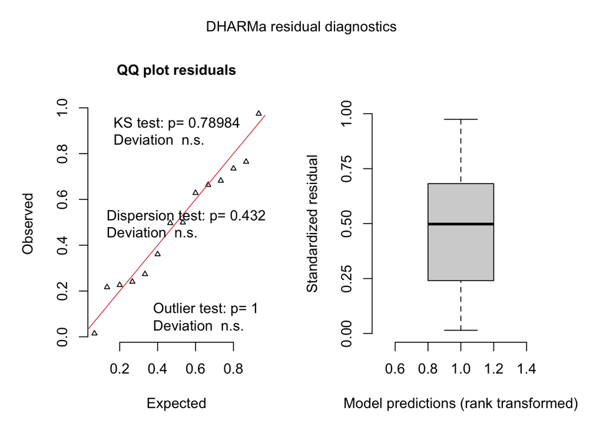

```r
simulationOutput <- simulateResiduals(fittedModel = lab_null)
fit <- plot(simulationOutput, asFactor=TRUE)
```

```r
zi <- testZeroInflation(simulationOutput)
```

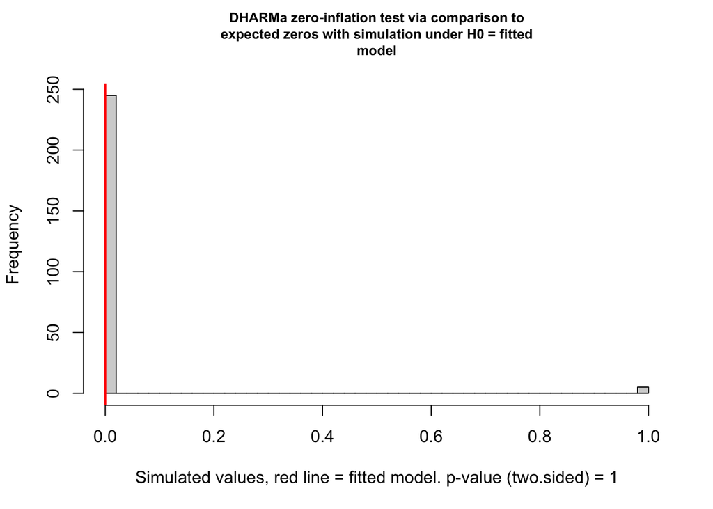

```r
od <- testDispersion(simulationOutput)
```

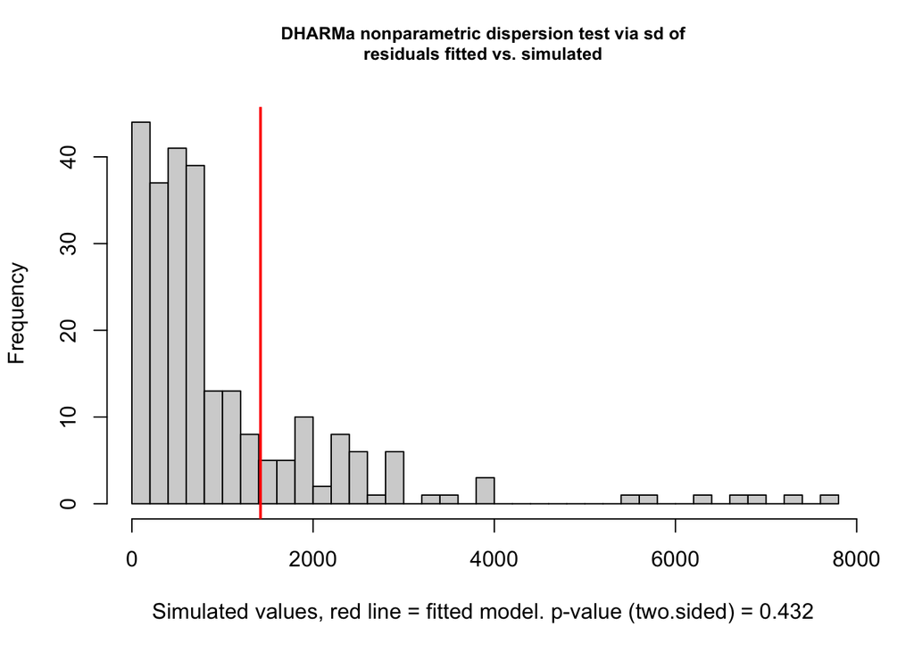

### B. Natural

For natural consumers, the full model is of the form:

**prey ~ Sterilized, offset = log(total), family = “genpois”)**

where **prey** is the abundance of potential prey DNA in the sample, **Sterilized** is a two-level factor of either *surface sterilized* or *not surface sterilized*, and the offset term of **total** offset transforms the abundance value by the total DNA read abundance in the sample, since there is a huge spread in the raw DNA abundances.

```r
AIC(fld_mod, fld_null)
```

|  | df | AIC |
| --- | --- | --- |
| fld_mod | 3 | 355.8463 |
| fld_null | 2 | 353.8582 |

#### Model summary

```r
summary(fld_mod)
```

```
##  Family: genpois  ( log )
## Formula:          prey ~ Sterilized
## Data: fld_all_nz
##  Offset: log(total)
##
##      AIC      BIC   logLik deviance df.resid
##    355.8    360.3   -174.9    349.8       30
##
##
## Overdispersion parameter for genpois family (): 1.37e+04
##
## Conditional model:
##              Estimate Std. Error z value Pr(>|z|)
## (Intercept)   -3.8924     1.1468  -3.394 0.000688 ***
## SterilizedSS  -0.0346     0.3178  -0.109 0.913303
## ---
## Signif. codes:  0 '***' 0.001 '**' 0.01 '*' 0.05 '.' 0.1 ' ' 1
```

```r
summary(fld_null)
```

```
##  Family: genpois  ( log )
## Formula:          prey ~ 1
## Data: fld_all_nz
##  Offset: log(total)
##
##      AIC      BIC   logLik deviance df.resid
##    353.9    356.9   -174.9    349.9       31
##
##
## Overdispersion parameter for genpois family (): 1.37e+04
##
## Conditional model:
##             Estimate Std. Error z value Pr(>|z|)
## (Intercept)   -3.909      1.137  -3.438 0.000586 ***
## ---
## Signif. codes:  0 '***' 0.001 '**' 0.01 '*' 0.05 '.' 0.1 ' ' 1
```

#### Model diagnostics

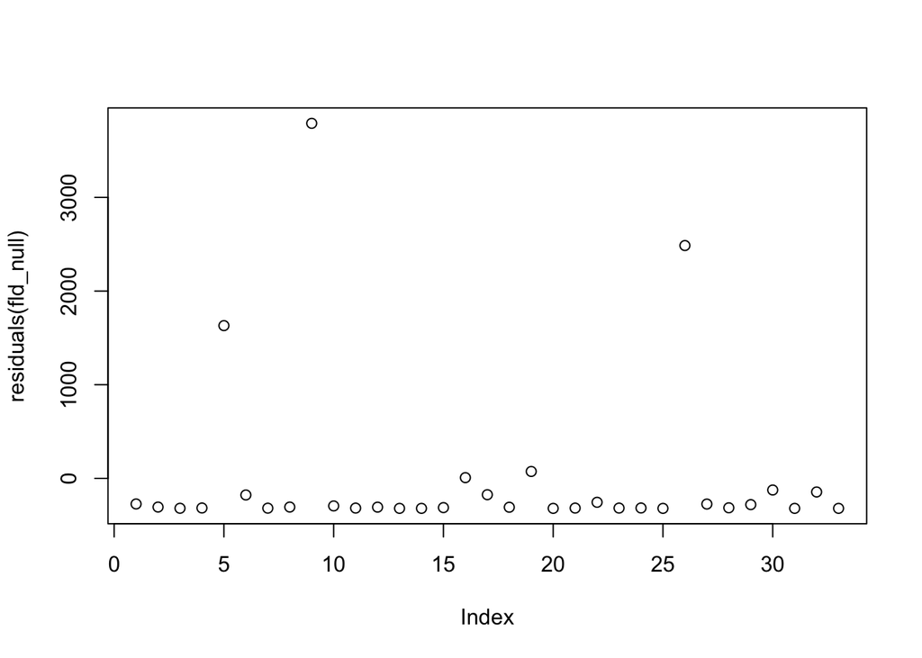

```r
plot(residuals(fld_null))
```

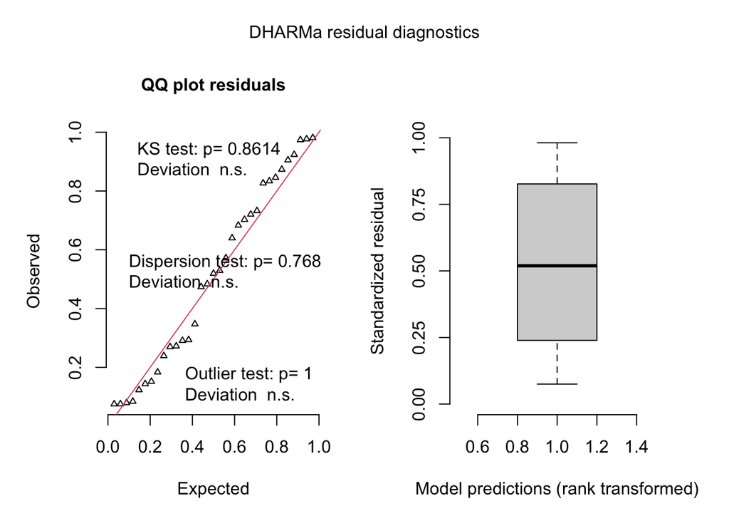

```r
simulationOutput <- simulateResiduals(fittedModel = fld_null)
fit <- plot(simulationOutput, asFactor=TRUE)
```

```r
zi <- testZeroInflation(simulationOutput)
```

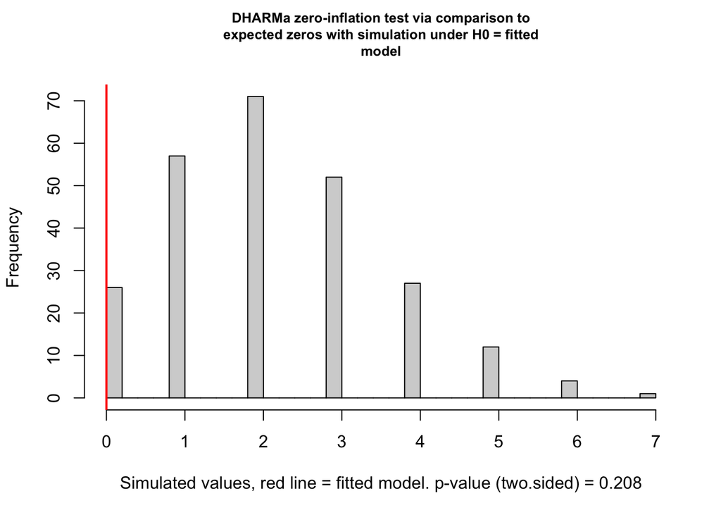

```r
od <- testDispersion(simulationOutput)
```

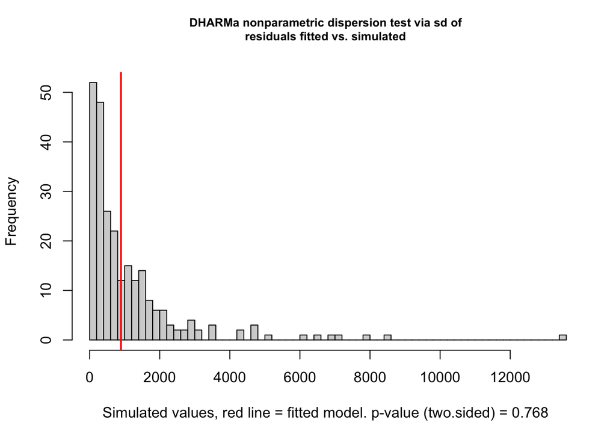

### C. Summary

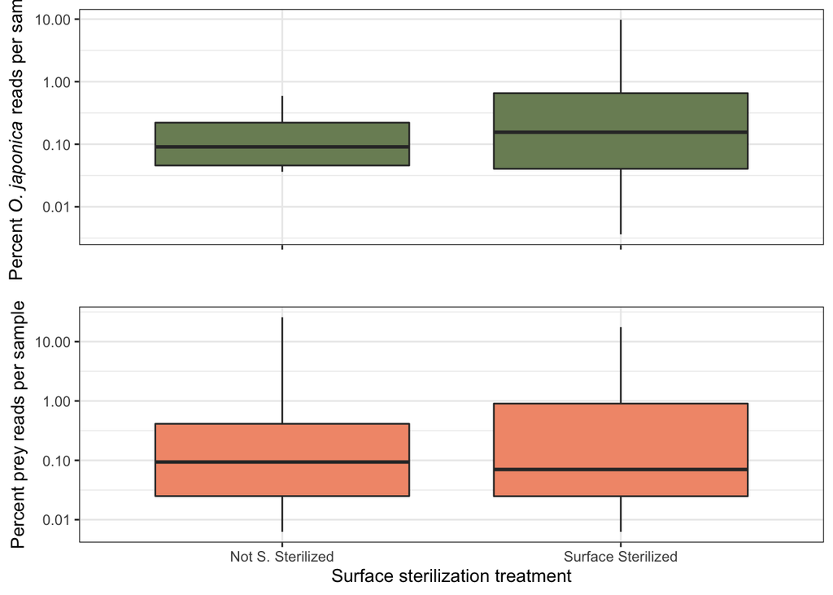

## 3. Natural: Prey DNA Richness and Composition

### A. Richness

We looked at richness of diet within each natural predator diet, with richness being the richness of family-level taxonomic assignments in each sample. The full model for richness is:

**SR ~ Sterilized, family = poisson**

where **SR** is taxonomic richness in a sample (concatenated at the family level) and **Sterilized** is a two-level factor of either *surface sterilized* or *not surface sterilized*.

#### Model comparison with AICc

```r
AICc(rich_mod, rich_null)
```

|  | df | AICc |
| --- | --- | --- |
| rich_mod | 2 | 135.8017 |
| rich_null | 1 | 133.5740 |

#### Model summary

```r
#based on this summary, surface sterilizatoin treatment is
#non-significant.
summary(rich_mod)
```

```
##  Family: poisson  ( log )
## Formula:          SR ~ Sterilized
## Data: richness
##
##      AIC      BIC   logLik deviance df.resid
##    135.4    138.7    -65.7    131.4       35
##
##
## Conditional model:
##              Estimate Std. Error z value Pr(>|z|)
## (Intercept)   0.74444    0.15811   4.708  2.5e-06 ***
## SterilizedSS -0.02389    0.22809  -0.105    0.917
## ---
## Signif. codes:  0 '***' 0.001 '**' 0.01 '*' 0.05 '.' 0.1 ' ' 1
```

```r
summary(rich_null)
```

```
##  Family: poisson  ( log )
## Formula:          SR ~ 1
## Data: richness
##
##      AIC      BIC   logLik deviance df.resid
##    133.5    135.1    -65.7    131.5       36
##
##
## Conditional model:
##             Estimate Std. Error z value Pr(>|z|)
## (Intercept)   0.7329     0.1140   6.431 1.27e-10 ***
## ---
## Signif. codes:  0 '***' 0.001 '**' 0.01 '*' 0.05 '.' 0.1 ' ' 1
```

#### Model diagnostics

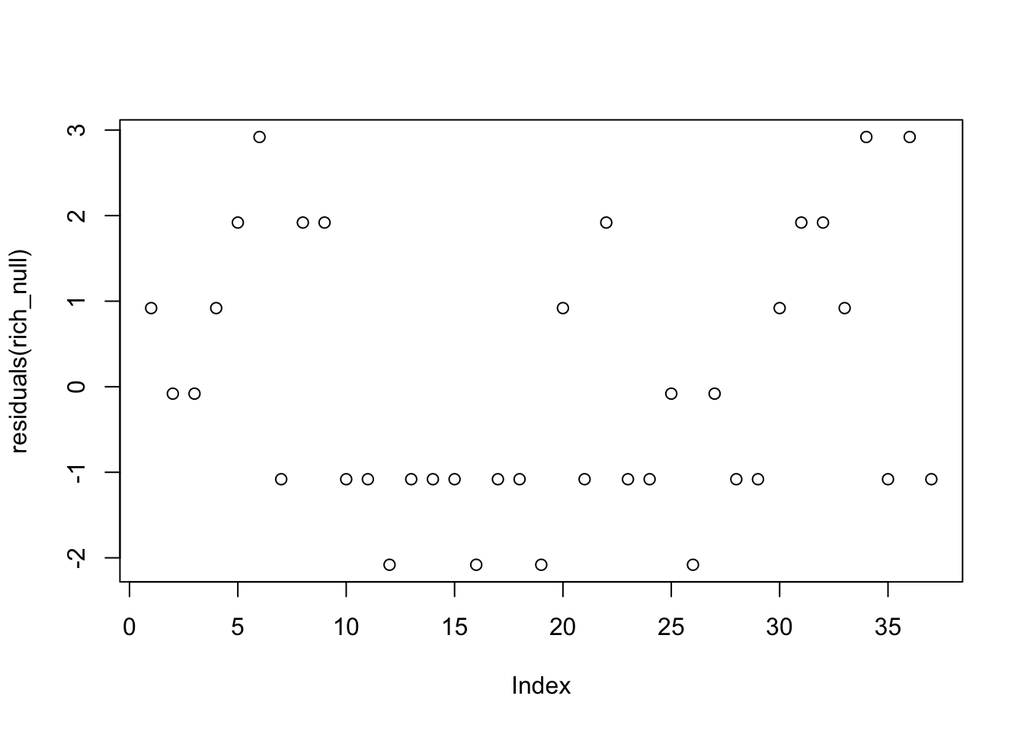

```r
plot(residuals(rich_null))
```

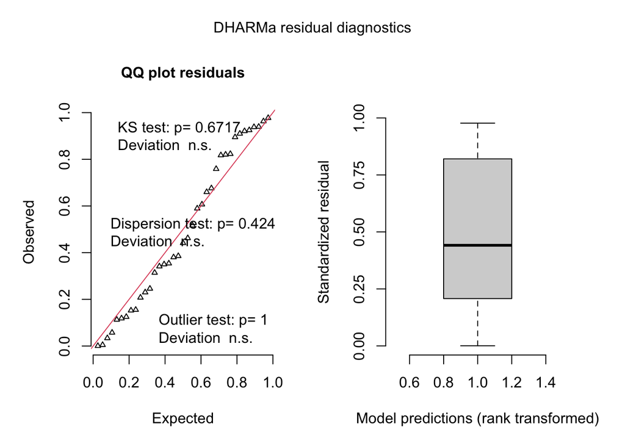

```r
simulationOutput <- simulateResiduals(fittedModel = rich_null)
fit <- plot(simulationOutput, asFactor=TRUE)
```

```r
zi <- testZeroInflation(simulationOutput)
```

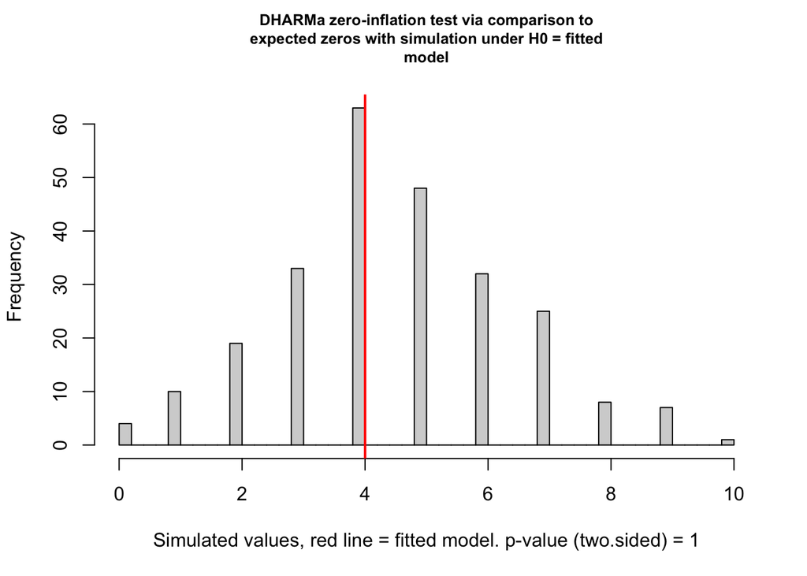

```r
od <- testDispersion(simulationOutput)
```

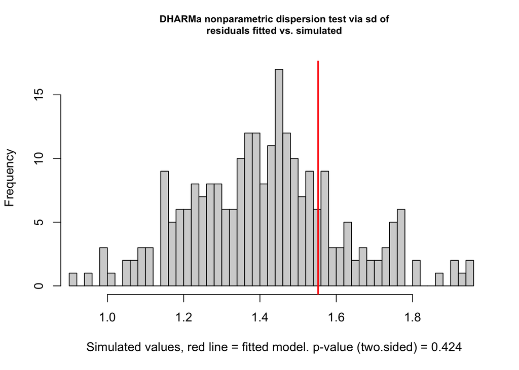

### B. Composition

We looked at presence-absence taxonomic composition of prey DNA using a GLMM-based PERMANOVA approach. Specifically, this GLMM is run by saying, how does the fixed effect of sterilization impact presence, with a random effects structure with both a random interept term for Family_ncbi (let each family have a different intercept) and a random slopes term for surface sterilization treatment (let each family’s relationship with with surface sterilization differ, ie let some families increase with surface sterilization, and others decrease)

The full model looks like:

**presence ~ Sterilized + (1+Sterilized|Family_ncbi), family = “binomial”**

And the null looks like:

**presence ~ 1 + (1|Family_ncbi), family = “binomial”**

#### Model comparison with AICc

```r
AICc(comp_mod, comp_null)
```

|  | df | AICc |
| --- | --- | --- |
| comp_mod | 5 | 468.1095 |
| comp_null | 2 | 462.0452 |

#### Model summary

```r
summary(comp_null)
```

```
##  Family: binomial  ( logit )
## Formula:          presence ~ 1 + (1 | Family_ncbi)
## Data: comp
##
##      AIC      BIC   logLik deviance df.resid
##      462      471     -229      458      658
##
## Random effects:
##
## Conditional model:
##  Groups      Name        Variance Std.Dev.
##  Family_ncbi (Intercept) 0.5887   0.7673
## Number of obs: 660, groups:  Family_ncbi, 20
##
## Conditional model:
##             Estimate Std. Error z value Pr(>|z|)
## (Intercept)  -2.2451     0.2282  -9.837   <2e-16 ***
## ---
## Signif. codes:  0 '***' 0.001 '**' 0.01 '*' 0.05 '.' 0.1 ' ' 1
```

```r
summary(comp_mod) #sterilization term not significant
```

```
##  Family: binomial  ( logit )
## Formula:          presence ~ Sterilized + (1 + Sterilized | Family_ncbi)
## Data: comp
##
##      AIC      BIC   logLik deviance df.resid
##    468.0    490.5   -229.0    458.0      655
##
## Random effects:
##
## Conditional model:
##  Groups      Name         Variance  Std.Dev. Corr
##  Family_ncbi (Intercept)  0.5985723 0.77367
##              SterilizedSS 0.0001757 0.01326  -1.00
## Number of obs: 660, groups:  Family_ncbi, 20
##
## Conditional model:
##              Estimate Std. Error z value Pr(>|z|)
## (Intercept)  -2.23856    0.27016  -8.286   <2e-16 ***
## SterilizedSS -0.01357    0.29549  -0.046    0.963
## ---
## Signif. codes:  0 '***' 0.001 '**' 0.01 '*' 0.05 '.' 0.1 ' ' 1
```

#### Model diagnostics

```r
binned_residuals(comp_null)
```

|  | xbar | ybar | n | x.lo | x.hi | se | group |
| --- | --- | --- | --- | --- | --- | --- | --- |
| 1 | 0.05811502 | -0.027811986 | 198 | 0.05811502 | 0.05811502 | 0.02442631 | no |
| 2 | 0.07463188 | -0.014025816 | 132 | 0.07463188 | 0.07463188 | 0.04169426 | yes |
| 3 | 0.09273763 | -0.001828536 | 66 | 0.09273763 | 0.09273763 | 0.07131496 | yes |
| 4 | 0.11214626 | 0.009065860 | 66 | 0.11214626 | 0.11214626 | 0.08096333 | yes |
| 5 | 0.13261815 | 0.018897006 | 33 | 0.13261815 | 0.13261815 | 0.12676667 | yes |
| 6 | 0.15395869 | 0.027859492 | 33 | 0.15395869 | 0.15395869 | 0.13636364 | yes |
| 7 | 0.17601177 | 0.036109442 | 33 | 0.17601177 | 0.17601177 | 0.14453624 | yes |
| 8 | 0.24531124 | 0.057719062 | 33 | 0.24531124 | 0.24531124 | 0.16248190 | yes |
| 9 | 0.24531124 | 0.057719062 | 33 | 0.24531124 | 0.24531124 | 0.16248190 | yes |
| 10 | 0.26918053 | 0.064152800 | 33 | 0.26918053 | 0.26918053 | 0.16666667 | yes |

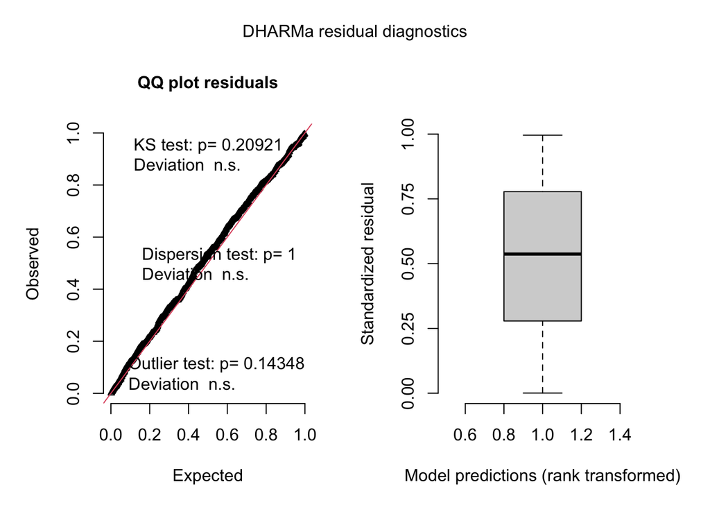

```r
simulationOutput <- simulateResiduals(fittedModel = comp_null)
fit <- plot(simulationOutput, asFactor=TRUE)
```

#### Supplementary: Compare to adonis()

The results are similar with an adonis() call from vegan, with the structure:

**comp1 ~ Sterilized, data = meta_field, dist = “jaccard”, binary = TRUE**

Where **comp1** is a matrix of interactions by individual, **Sterilized** is a binary fixed effect. We selected the Jaccard dissimilarlity index (indicating that data are presence-absence with binary=TRUE) since the Jaccard dissimilarity index is functionally Bray-Curtis dissimilarity, but better suited for presence-absence data

```r
adonis(comp1 ~ Sterilized, data = meta_field, dist = "jaccard", binary = TRUE)
```

```
##
## Call:
## adonis(formula = comp1 ~ Sterilized, data = meta_field, dist = "jaccard",      binary = TRUE)
##
## Permutation: free
## Number of permutations: 999
##
## Terms added sequentially (first to last)
##
##            Df SumsOfSqs MeanSqs F.Model      R2 Pr(>F)
## Sterilized  1    0.0462 0.04625   0.113 0.00363  0.999
## Residuals  31   12.6870 0.40926         0.99637
## Total      32   12.7333                 1.00000
```

### C. Summary

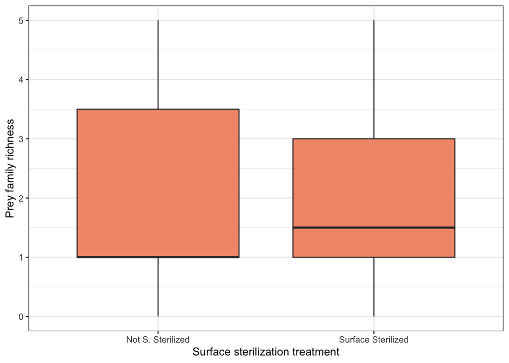

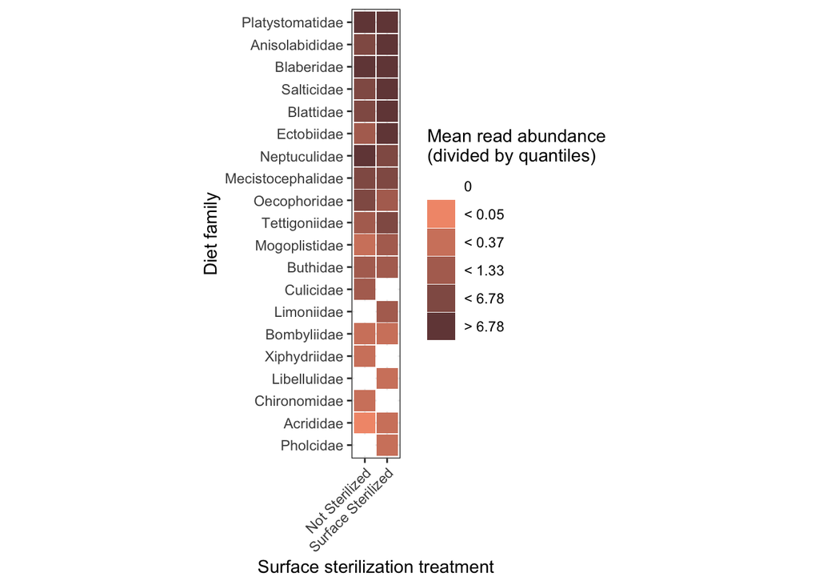